# AKFIN_WebService_Short

Jordan Watson/Matt Callahan

2/22/2021

```r
library(httr)
library(tidyverse)
library(lubridate)
library(sp)
library(rgdal)
library(ggrepel)
```

### Introduction:

Satellite data provide information across broad spatial and temporal extents. These data are often valuable for stock assessments or other fishery evaluations when linked with biological or fishery data. The Alaska Fisheries Science Center worked with the Alaska Fisheries Information Network (AKFIN) at Pacific States Marine Fisheries Commission to develop an easy and efficient satellite sea surface temperature (SST) data extraction process for spatial strata that are commonly used by Alaska fisheries scientists and managers.

Satellite SST data from the NOAA Coral Reef Watch Program (Skirving 2020; https://coralreefwatch.noaa.gov/product/5km/index_5km_sst.php) are downloaded daily for the entire spatial extent of the U.S. exclusive economic zone around Alaska. The time series begins 1/1/1985 and extends through the present (all data were sourced from Coral Reef Watch except 1/1/1985-3/31/1985, which were sourced from NOAA National Environmental Satellite Data and Information Service). For the Bering Sea and Gulf of Alaska, the query filters only data where water depth is between 10 and 200m. For the Aleutian Islands, a depth filter does not exist. The full gridded dataset is available to users with an AKFIN database account and can be easily queried from Oracle, R, or Python. Alternatively, anyone can access data that are already averaged across one of several dozen commonly used spatial strata, including each of the NMFS management areas, each of the ecosystem regions used for annual presentations to the North Pacific Fishery Management Council, the BSIERP regions, and the ADF&G statistical areas (Fig. 1).

For users that have custom spatial strata, whether different lat/lon bounds, different depth ranges, or custom shapefiles, they can contact us to discuss creating a custom URL query for them.

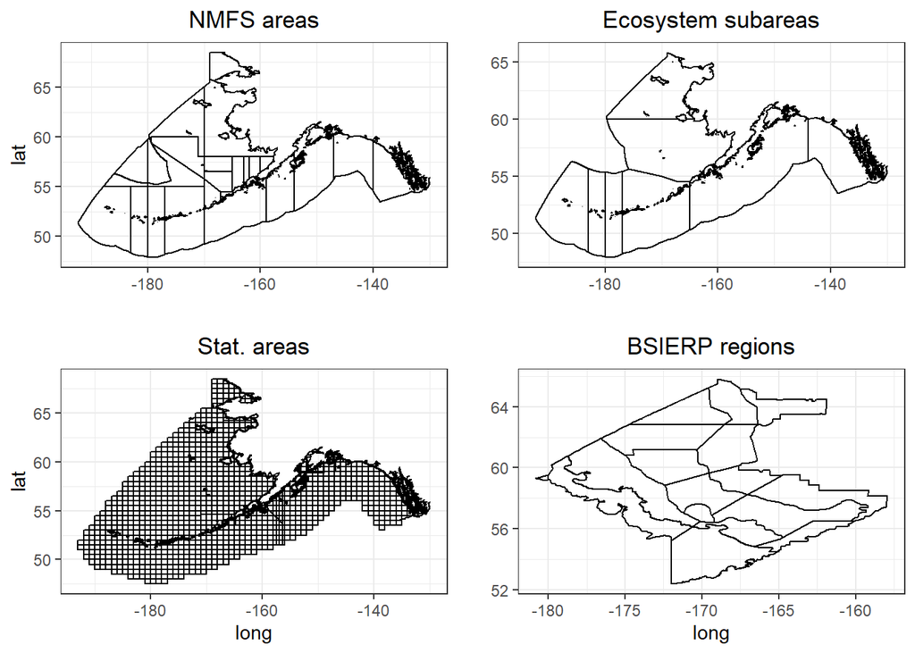

Fig. 1. Map of four commonly used spatial strata for which SST data are averaged daily.

With this tool, users can easily incorporate SST data into stock assessments and other processes, for example one could plot a time series of average summer SST for NMFS areas 640 and 650 (Fig. 2)

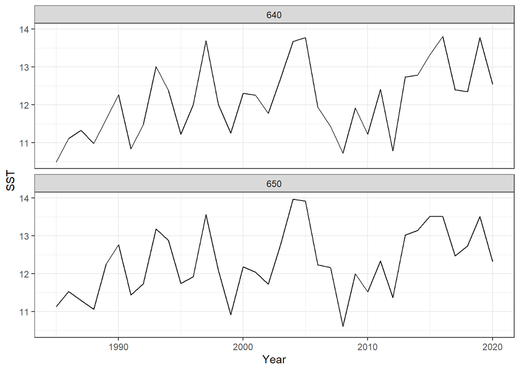

Fig. 2. June-August SST 1985-2020 in EGOA NMFS areas.

```r
httr::content(httr::GET('https://apex.psmfc.org/akfin/data_marts/akmp/nmfs_area_crw_avg_sst?nmfs_area=640,650&start_date=19850401&end_date=20220101'), type = "application/json") %>%
  bind_rows %>%
  mutate(MONTH=month(as_date(READ_DATE))) %>%
  filter(MONTH==6 | MONTH==7 | MONTH==8) %>%
  group_by(YEAR,NMFSAREA)%>%
    summarize(SST=mean(MEANSST))%>%
  ggplot(aes(as.numeric(YEAR),SST)) +
  geom_line() +
  facet_wrap(~NMFSAREA, nrow=2) +
  xlab("Year") +
  theme_bw()
```

### Web Service-How It Works:

```r
#View strata included in the lookup table
lkp <- readRDS("Data/crwsst_spatial_lookup_table.RDS")
str(lkp)
```

```
## 'data.frame':    212814 obs. of  11 variables:
##  $ id           : int  1742 1743 1744 1745 1746 1747 1748 1749 1750 1751 ...
##  $ statefed     : Factor w/ 3 levels "FED","INTL","STATE": 1 1 1 1 1 1 1 1 1 1 ...
##  $ stat_area    : num  686800 686800 686800 686800 686800 ...
##  $ depth        : num  -54 -54 -54 -53 -53 -51 -50 -50 -50 -50 ...
##  $ longitude    : num  -169 -169 -169 -169 -169 ...
##  $ latitude     : num  68.5 68.5 68.5 68.5 68.5 ...
##  $ nmfsarea     : Factor w/ 25 levels "400","508","509",..: 1 1 1 1 1 1 1 1 1 1 ...
##  $ bsierp_id    : int  NA NA NA NA NA NA NA NA NA NA ...
##  $ bsierp_name  : Factor w/ 16 levels "AK peninsula",..: NA NA NA NA NA NA NA NA NA NA ...
##  $ Ecosystem    : chr  NA NA NA NA ...
##  $ Ecosystem_sub: chr  NA NA NA NA ...
```

The web service enables us to query data using a URL, where the URL itself contains information for querying data from the server. One could paste the URL below into a browser and view the output there if desired. In the first example we will query SST within a NMFS area. Currently, NMFS areas can be queried individually (daily means calculated for each NMFS area). We query the URL “https://apex.psmfc.org/akfin/data_marts/akmp/nmfs_area_crw_avg_sst?nmfs_area=640”, where “nmfs_area_crw_avg_sst?” is the name of the dataset we are querying. This is the daily CRW SST dataset, which has been averaged by the field **nmfs_area**. A “?” separates the dataset name from the query criteria. The default behavior is to pull a single record, the most recent in the data set. The web service encodes the data as “json” so R must be told how to decode the data using the type = “application/json” argument.

```r
httr::content(httr::GET("https://apex.psmfc.org/akfin/data_marts/akmp/nmfs_area_crw_avg_sst?nmfs_area=640"), type = "application/json")%>%
  bind_rows
```

```
## # A tibble: 1 x 5
##   MEANSST NMFSAREA READ_DATE            YEAR  JULIAN
##     <dbl> <chr>    <chr>                <chr> <chr>
## 1    4.81 640      2021-03-06T12:00:00Z 2021  065
```

```r
#By default the URL returns a list. We use "%>% bind_rows" here to convert to a data frame (tibble)
```

### Time Periods:

It is unlikely that you want a single temperature record. To instead query a time period, the user can specify a new time parameter to the URL with an “&” delimiter. Users can query a time period using “start_date” and “end_date”, “read_date”, or “dates_back” parameters. Note that date is sufficient, it is not necessary to specify a time component in the query.

Most users will want to query the entire duration of the time series, which for the CRW SST dataset begins on 1985-04-01. To query the entire time series, specify “start_date” & “end_date”. “end_date” must be included, but if you do not know the most recent date of the time series, you can choose an end date some time far in the future and it will query all of the data that exist without an error.

```r
data <- httr::content(httr::GET('https://apex.psmfc.org/akfin/data_marts/akmp/nmfs_area_crw_avg_sst?nmfs_area=640&start_date=19850401&end_date=20220101'), type = "application/json") %>%
  bind_rows

head(data)
```

```
## # A tibble: 6 x 5
##   MEANSST NMFSAREA READ_DATE            YEAR  JULIAN
##     <dbl> <chr>    <chr>                <chr> <chr>
## 1    4.35 640      1985-04-01T12:00:00Z 1985  091
## 2    4.36 640      1985-04-02T12:00:00Z 1985  092
## 3    4.5  640      1985-04-03T12:00:00Z 1985  093
## 4    4.64 640      1985-04-04T12:00:00Z 1985  094
## 5    4.74 640      1985-04-05T12:00:00Z 1985  095
## 6    4.84 640      1985-04-06T12:00:00Z 1985  096
```

The full time series yields more than 13,000 rows of data per area (i.e., daily data from 1985-04-01 to present).

```r
dim(data)
```

```
## [1] 13120     5
```

Any time range can be chosen with “start_date” and “end_date”, for example if one wanted to pull SST in NMFS area 640 in 1987 (Fig. 3).

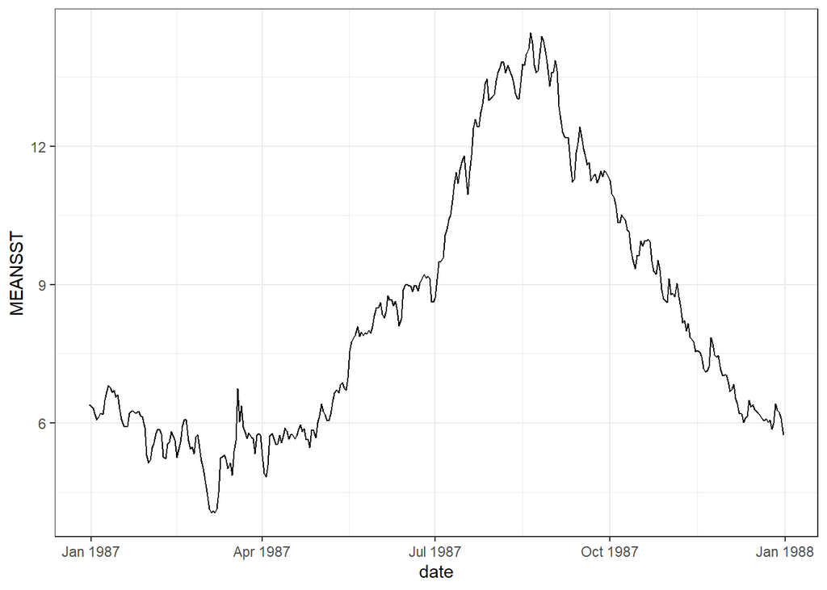

Fig. 3. 1987 SST in NMFS 640.

```r
httr::content(httr::GET('https://apex.psmfc.org/akfin/data_marts/akmp/nmfs_area_crw_avg_sst?nmfs_area=640&start_date=19870101&end_date=19880101'), type = "application/json") %>%
  bind_rows %>%
  mutate(date=as_date(READ_DATE)) %>%
  ggplot(aes(date,MEANSST)) +
  geom_line()+
  theme_bw()
```

You can query a specific date with “read_date”. For example SST in MFS 640 on Y2K.

```r
#Query the day after your date of interest because omitting the time component in read_date misses that day's reading.
httr::content(httr::GET('https://apex.psmfc.org/akfin/data_marts/akmp/nmfs_area_crw_avg_sst?nmfs_area=640&read_date=20000102'), type = "application/json") %>%
  bind_rows
```

```
## # A tibble: 1 x 5
##   MEANSST NMFSAREA READ_DATE            YEAR  JULIAN
##     <dbl> <chr>    <chr>                <chr> <chr>
## 1    5.07 640      2000-01-01T12:00:00Z 2000  001
```

You can specify a number of days prior to any date using a “days_back” parameter specification. For example the three days before Y2K.

```r
httr::content(httr::GET('https://apex.psmfc.org/akfin/data_marts/akmp/nmfs_area_crw_avg_sst?nmfs_area=640&read_date=20000101&days_back=2'), type = "application/json") %>%
  bind_rows
```

```
## # A tibble: 3 x 5
##   MEANSST NMFSAREA READ_DATE            YEAR  JULIAN
##     <dbl> <chr>    <chr>                <chr> <chr>
## 1    5.43 640      1999-12-29T12:00:00Z 1999  363
## 2    5.13 640      1999-12-30T12:00:00Z 1999  364
## 3    4.94 640      1999-12-31T12:00:00Z 1999  365
```

If “read_date” is not specified, “days_back” returns the most recent SSTs. Here are SSTs for the last three days in NMFS 640.

```r
httr::content(httr::GET('https://apex.psmfc.org/akfin/data_marts/akmp/nmfs_area_crw_avg_sst?nmfs_area=640&days_back=2'), type = "application/json") %>%
  bind_rows
```

```
## # A tibble: 3 x 5
##   MEANSST NMFSAREA READ_DATE            YEAR  JULIAN
##     <dbl> <chr>    <chr>                <chr> <chr>
## 1    4.83 640      2021-03-04T12:00:00Z 2021  063
## 2    4.79 640      2021-03-05T12:00:00Z 2021  064
## 3    4.81 640      2021-03-06T12:00:00Z 2021  065
```

### Spatial Extents:

To query multiple areas, separate the values by a comma. For example to query NMFS areas 640 and 650 (Southeast Alaska outside waters):

```r
httr::content(httr::GET("https://apex.psmfc.org/akfin/data_marts/akmp/nmfs_area_crw_avg_sst?nmfs_area=640,650"), type = "application/json")%>%
  bind_rows
```

```
## # A tibble: 2 x 5
##   MEANSST NMFSAREA READ_DATE            YEAR  JULIAN
##     <dbl> <chr>    <chr>                <chr> <chr>
## 1    4.81 640      2021-03-06T12:00:00Z 2021  065
## 2    5.69 650      2021-03-06T12:00:00Z 2021  065
```

The **Ecosystem_sub** field in our lookup table contains all of the different ecosystem regions that can be queried from the data. Points outside these ecosystem regions are listed as NA for this field.

```r
unique(lkp$Ecosystem_sub)
```

```
## [1] NA                        "Northern Bering Sea"
## [3] "Western Gulf of Alaska"  "Eastern Gulf of Alaska"
## [5] "Southeastern Bering Sea" "Eastern Aleutians"
## [7] "Central Aleutians"       "Western Aleutians"
```

To query the data for the “Southeastern Bering Sea”, for example, add “ecosystem_sub=Southeastern%20Bering%20Sea”, where spaces are filled by “%20”.

```r
httr::content(httr::GET('https://apex.psmfc.org/akfin/data_marts/akmp/ecosystem_sub_crw_avg_sst?ecosystem_sub=Southeastern%20Bering%20Sea'), type = "application/json") %>%
  bind_rows
```

```
## # A tibble: 1 x 5
##   MEANSST ECOSYSTEM_SUB           READ_DATE            YEAR  JULIAN
##     <dbl> <chr>                   <chr>                <chr> <chr>
## 1    0.95 Southeastern Bering Sea 2021-03-06T12:00:00Z 2021  065
```

Putting the pieces all together, the data can be queried directly from AKFIN and saved, manipulated, or visualized directly. Here we query the full time series for the Eastern Gulf of Alaska and for the Eastern Aleutian Islands (Fig. 4.).

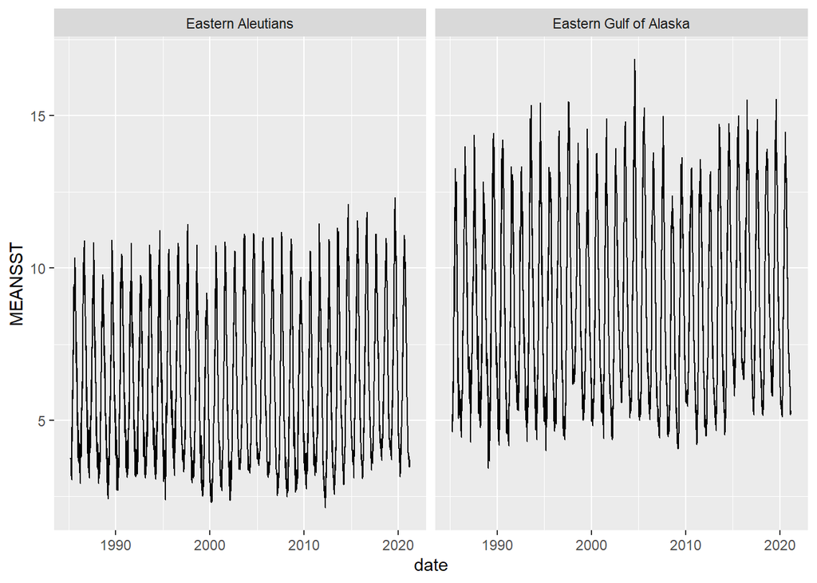

Fig. 4. SST for the full time series in two ecosystem subregions.

```r
httr::content(httr::GET('https://apex.psmfc.org/akfin/data_marts/akmp/ecosystem_sub_crw_avg_sst?ecosystem_sub=Eastern%20Gulf%20of%20Alaska,Eastern%20Aleutians&start_date=19850401&end_date=20220101'), type = "application/json") %>%
  bind_rows %>%
  mutate(date=as_date(READ_DATE)) %>%
  ggplot(aes(date,MEANSST)) +
  geom_line() +
  facet_wrap(~ECOSYSTEM_SUB)
```

One could query and summarize data by month (week, year, etc) by simply grouping and summarizing the data in-line. Because the most recent year will be incomplete, its annual mean will be wonky (Fig. 5.).

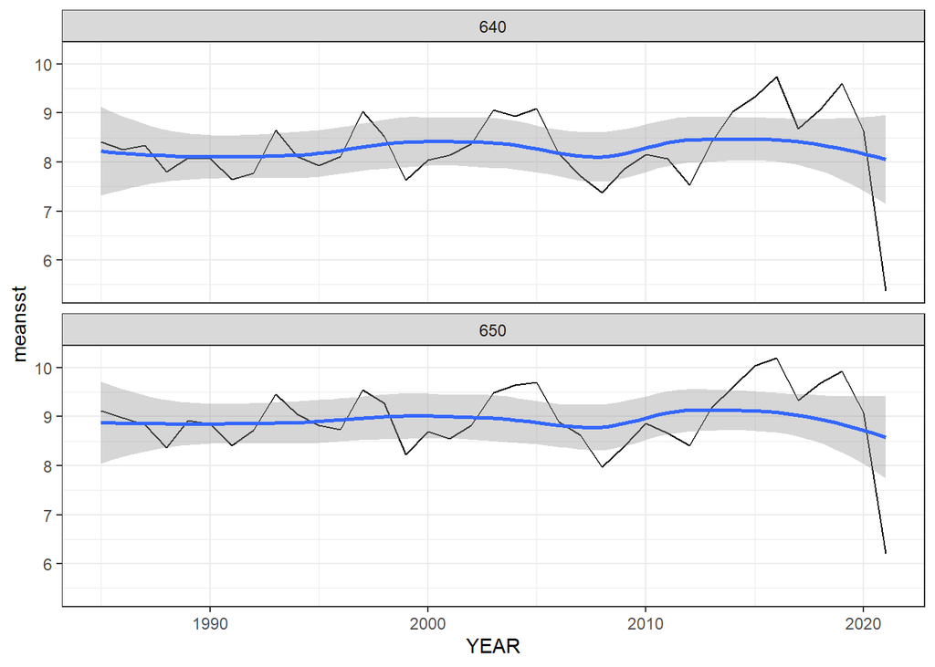

Fig. 5. Mean annual SST in EGOA NMFS areas.

```r
#Note that year is a character so it needs to be converted to an integer for continuous plotting.
httr::content(httr::GET('https://apex.psmfc.org/akfin/data_marts/akmp/nmfs_area_crw_avg_sst?nmfs_area=640,650&start_date=19850401&end_date=20220101'), type = "application/json") %>%
  bind_rows %>%
  mutate(date=as_date(READ_DATE),
         YEAR=as.numeric(YEAR)) %>%
  group_by(YEAR,NMFSAREA) %>%
  summarise(meansst=mean(MEANSST)) %>%
  ggplot(aes(YEAR,meansst)) +
  geom_line() +
  geom_smooth() +
  facet_wrap(~NMFSAREA, nrow=2)+
  theme_bw()
```

### Extensions:

Once you have daily time series for a spatial stratum it’s really straightforward to use the heatwaveR package to characterize marine heatwaves (MHWs) in your data. The package vignette is fantastic (https://robwschlegel.github.io/heatwaveR/). We’ll demonstrate a few quick examples below using our time series for NMFS area 640 (Eastern GOA). To keep this document short we only demonstrate plotting a single stratum but please contact us for additional code examples with multiple spatial strata if you are interested. We’re happy to help with any indicator development.

```r
library(heatwaveR)
updateddata <- httr::content(httr::GET('https://apex.psmfc.org/akfin/data_marts/akmp/nmfs_area_crw_avg_sst?nmfs_area=640&start_date=19850401&end_date=20211231'), type = "application/json") %>%
  bind_rows %>%
  mutate(date=as_date(READ_DATE)) %>%
  data.frame %>%
  dplyr::select(date,meansst=MEANSST,NMFSAREA) #I just simplify my data frame
```

The detect_event() and the ts2clm() functions will analyze your dataset for marine heatwave status given a particular baseline period. We specify the earliest 30-years as a baseline by convention. The ts2clm() function generates marine heatwave thresholds from your baseline period. The detect_event() function creates a list of 2 data frames. The first, **climatology**, adds a series of columns to your data frame, including the seasonal climatology and MHW thresholds as well as flags for whether or not a record falls within a MHW. The second list object, **event**, includes summary information about each of the MHW events (e.g., max intensity, duration, start and end dates, etc.).

```r
mhw <- detect_event(ts2clm(updateddata %>%
                              rename(t=date,temp=meansst) %>%
                              arrange(t), climatologyPeriod = c("1985-04-01", "2015-03-31"))) #Specify the baseline period.

str(mhw)
```

```
## List of 2
##  $ climatology: tibble [13,124 x 9] (S3: tbl_df/tbl/data.frame)
##   ..$ doy              : int [1:13124] 92 93 94 95 96 97 98 99 100 101 ...
##   ..$ t                : Date[1:13124], format: "1985-04-01" "1985-04-02" ...
##   ..$ temp             : num [1:13124] 4.35 4.36 4.5 4.64 4.74 4.84 4.9 4.86 4.68 4.52 ...
##   ..$ seas             : num [1:13124] 4.75 4.77 4.79 4.81 4.83 ...
##   ..$ thresh           : num [1:13124] 5.53 5.55 5.56 5.57 5.58 ...
##   ..$ threshCriterion  : logi [1:13124] FALSE FALSE FALSE FALSE FALSE FALSE ...
##   ..$ durationCriterion: logi [1:13124] FALSE FALSE FALSE FALSE FALSE FALSE ...
##   ..$ event            : logi [1:13124] FALSE FALSE FALSE FALSE FALSE FALSE ...
##   ..$ event_no         : int [1:13124] NA NA NA NA NA NA NA NA NA NA ...
##  $ event      : tibble [51 x 22] (S3: tbl_df/tbl/data.frame)
##   ..$ event_no                      : int [1:51] 1 2 3 4 5 6 7 8 9 10 ...
##   ..$ index_start                   : int [1:51] 585 628 648 661 688 717 1636 1652 2998 3050 ...
##   ..$ index_peak                    : int [1:51] 598 632 650 666 691 718 1637 1654 3004 3056 ...
##   ..$ index_end                     : int [1:51] 603 639 656 669 692 726 1640 1659 3007 3059 ...
##   ..$ duration                      : num [1:51] 19 12 9 9 5 10 5 8 10 10 ...
##   ..$ date_start                    : Date[1:51], format: "1986-11-06" "1986-12-19" ...
##   ..$ date_peak                     : Date[1:51], format: "1986-11-19" "1986-12-23" ...
##   ..$ date_end                      : Date[1:51], format: "1986-11-24" "1986-12-30" ...
##   ..$ intensity_mean                : num [1:51] 1.58 1.1 1.3 1.11 1.12 ...
##   ..$ intensity_max                 : num [1:51] 2.08 1.27 1.44 1.2 1.35 ...
##   ..$ intensity_var                 : num [1:51] 0.2995 0.1087 0.1371 0.0828 0.2434 ...
##   ..$ intensity_cumulative          : num [1:51] 29.98 13.2 11.67 10.01 5.62 ...
##   ..$ intensity_mean_relThresh      : num [1:51] 0.431 0.231 0.447 0.276 0.366 ...
##   ..$ intensity_max_relThresh       : num [1:51] 0.947 0.405 0.597 0.367 0.6 ...
##   ..$ intensity_var_relThresh       : num [1:51] 0.302 0.107 0.136 0.076 0.244 ...
##   ..$ intensity_cumulative_relThresh: num [1:51] 8.19 2.77 4.02 2.48 1.83 ...
##   ..$ intensity_mean_abs            : num [1:51] 9.13 6.9 6.62 6.18 5.86 ...
##   ..$ intensity_max_abs             : num [1:51] 9.54 7.17 6.81 6.27 6.08 ...
##   ..$ intensity_var_abs             : num [1:51] 0.32 0.188 0.152 0.112 0.241 ...
##   ..$ intensity_cumulative_abs      : num [1:51] 173.5 82.8 59.6 55.6 29.3 ...
##   ..$ rate_onset                    : num [1:51] 0.0686 0.0806 0.2091 0.0497 0.1705 ...
##   ..$ rate_decline                  : num [1:51] 0.1899 0.0536 0.0736 0.1681 0.3635 ...
```

To create the common “flame” plots for MHWs, simply extract the climatology object from the list and plot it. Below we will filter the data since 2018-12-01 for NMFS area 640. The plotting code here is just the default code from the heatwaveR vignettes. You can easily see how to customize the aesthetics in normal tidy fashion (Fig. 6.).

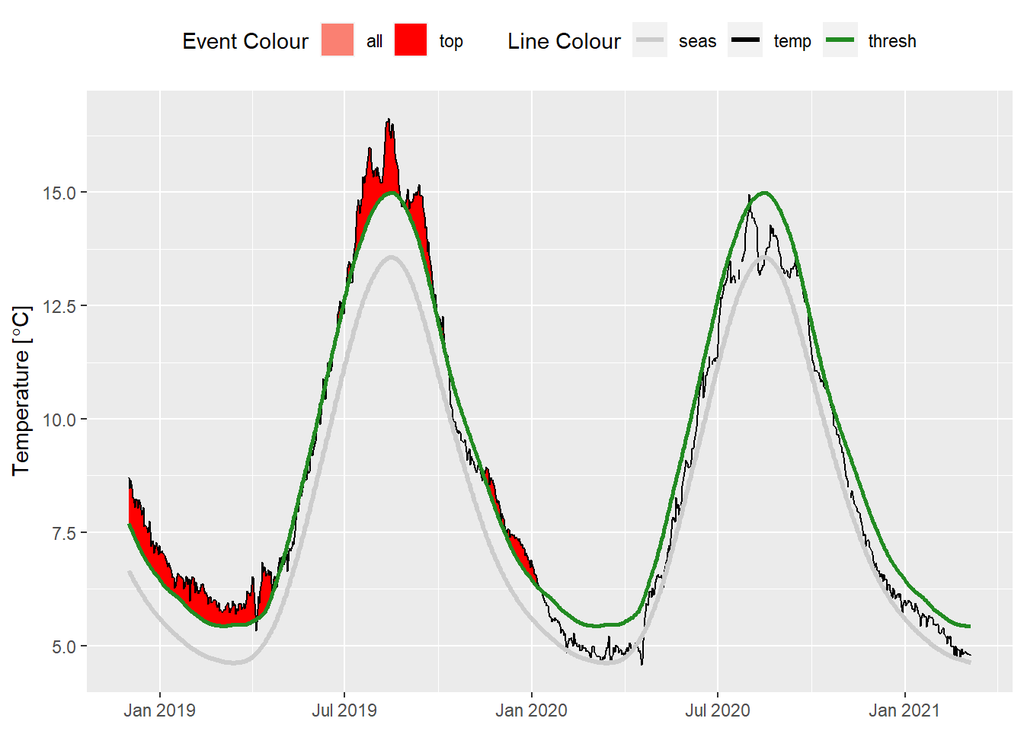

Fig. 6. Marine heatwave index flame plot for NMFS 640 Dec. 2018-present.

```r
mhw_clim <- mhw$climatology %>% filter(t>=as.Date("2018-12-01"))

ggplot(data = mhw_clim, aes(x = t)) +
  geom_flame(aes(y = temp, y2 = thresh, fill = "all"), show.legend = T) +
  geom_flame(data = mhw_clim, aes(y = temp, y2 = thresh, fill = "top"),  show.legend = T) +
  geom_line(aes(y = temp, colour = "temp")) +
  geom_line(aes(y = thresh, colour = "thresh"), size = 1.0) +
  geom_line(aes(y = seas, colour = "seas"), size = 1.2) +
  scale_colour_manual(name = "Line Colour",
                      values = c("temp" = "black",
                                 "thresh" =  "forestgreen",
                                 "seas" = "grey80")) +
  scale_fill_manual(name = "Event Colour",
                    values = c("all" = "salmon",
                               "top" = "red")) +
  scale_x_date(date_labels = "%b %Y") +
  guides(colour = guide_legend(override.aes = list(fill = NA))) +
  labs(y = expression(paste("Temperature [", degree, "C]")), x = NULL) +
  theme(legend.position="top")
```

You can also tweak the image slightly to add the intensity categories of the MHWs. Again, the plotting code is verbatim from the heatwaveR vignettes. To illustrate the categories a bit better, here we switch data sets to the Northern Bering Sea ecosystem region. We have also consolidated some of the code to reduce the number of intermediate objects and we filter the data from 2019-01-01 to 2019-12-31 (Fig. 7).

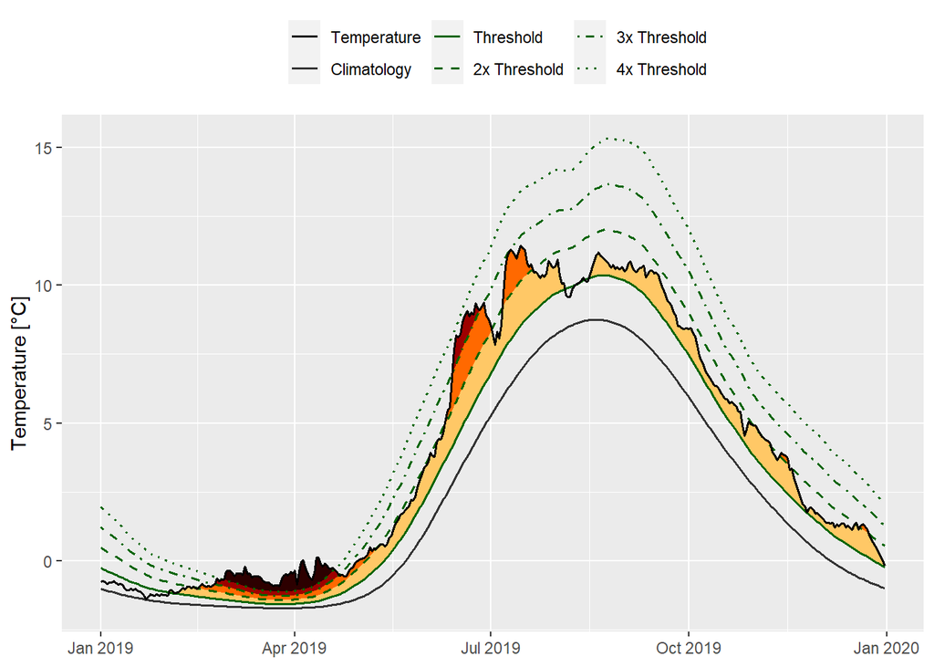

Fig. 7. 2019 MHW intesity for the Northern Bering Sea.

```r
updateddata <- httr::content(httr::GET('https://apex.psmfc.org/akfin/data_marts/akmp/ecosystem_sub_crw_avg_sst?ecosystem_sub=Northern%20Bering%20Sea&start_date=19850401&end_date=20211231'), type = "application/json") %>%
  bind_rows %>%
  mutate(date=as_date(READ_DATE)) %>%
  data.frame %>%
  dplyr::select(date,meansst=MEANSST) #I just simplify my data frame

clim_cat <- (detect_event(ts2clm(updateddata %>%
                              rename(t=date,temp=meansst) %>%
                              arrange(t), climatologyPeriod = c("1985-04-01", "2015-03-31"))))$climatology %>% #Specify the baseline period.
  dplyr::mutate(diff = thresh - seas,
                thresh_2x = thresh + diff,
                thresh_3x = thresh_2x + diff,
                thresh_4x = thresh_3x + diff) %>%
  filter(t>=as.Date("2019-01-01") & t<=as.Date("2019-12-31")) # Select the time period to display.

# Set line colours
lineColCat <- c(
  "Temperature" = "black",
  "Climatology" = "gray20",
  "Threshold" = "darkgreen",
  "2x Threshold" = "darkgreen",
  "3x Threshold" = "darkgreen",
  "4x Threshold" = "darkgreen"
  )

# Set category fill colours
fillColCat <- c(
  "Moderate" = "#ffc866",
  "Strong" = "#ff6900",
  "Severe" = "#9e0000",
  "Extreme" = "#2d0000"
  )


ggplot(data = clim_cat, aes(x = t, y = temp)) +
  geom_flame(aes(y2 = thresh, fill = "Moderate")) +
  geom_flame(aes(y2 = thresh_2x, fill = "Strong")) +
  geom_flame(aes(y2 = thresh_3x, fill = "Severe")) +
  geom_flame(aes(y2 = thresh_4x, fill = "Extreme")) +
  geom_line(aes(y = thresh_2x, col = "2x Threshold"), size = 0.7, linetype = "dashed") +
  geom_line(aes(y = thresh_3x, col = "3x Threshold"), size = 0.7, linetype = "dotdash") +
  geom_line(aes(y = thresh_4x, col = "4x Threshold"), size = 0.7, linetype = "dotted") +
  geom_line(aes(y = seas, col = "Climatology"), size = 0.7) +
  geom_line(aes(y = thresh, col = "Threshold"), size = 0.7) +
  geom_line(aes(y = temp, col = "Temperature"), size = 0.6) +
  scale_colour_manual(name = NULL, values = lineColCat,
                      breaks = c("Temperature", "Climatology", "Threshold",
                                 "2x Threshold", "3x Threshold", "4x Threshold")) +
  scale_fill_manual(name = NULL, values = fillColCat, guide = FALSE) +
  scale_x_date(date_labels = "%b %Y") +
  guides(colour = guide_legend(override.aes = list(linetype = c("solid", "solid", "solid",
                                                                "dashed", "dotdash", "dotted"),
                                                   size = c(0.6, 0.7, 0.7, 0.7, 0.7, 0.7)))) +
  labs(y = "Temperature [°C]", x = NULL) +
  theme(legend.position="top")
```

References Skirving, W; Marsh, B; De La Cour, J; Liu, G; Harris, A; Maturi, E; Geiger, E; Eakin, CM. CoralTemp and the Coral Reef Watch Coral Bleaching Heat Stress Product Suite Version 3.1. Remote Sens. 2020, 12, 3856; https://doi.org/10.3390/rs12233856.